# Severe Weather Impact in the United States

Major health and economic impacts pulled from NOAA Storm Database

Charles Tilford

## Summary

This analysis is the [second assignment](https://www.coursera.org/learn/reproducible-research/peer/OMZ37/course-project-2) of the Coursera [Reporducible Research](https://www.coursera.org/learn/reproducible-research) class. The data are from the [NOAA Storm Data Publication](https://www.ncdc.noaa.gov/oa/climate/sd/) service, provided from a [cache on CloudFront](https://d396qusza40orc.cloudfront.net/repdata%2Fdata%2FStormData.csv.bz2) (**47Mb file!!**). The assignment asks that the following two questions be addressed:

1. Across the United States, which types of events (as indicated in the EVTYPE variable) are most harmful with respect to population health?
   - *Nutshell*: **Heat** and **tornadoes** pose the greatest threat to health, with flooding causing sporadic significant events
2. Across the United States, which types of events have the greatest economic consequences?
   - *Nutshell*: **Tornados** are a constant, significant destoryer of property, but **hurricanes** and **flooding** sporadically cause immense property damage. Crops are most affected by **drought**, **ice** and **flooding**, with **hurricanes** also wreaking occasional major impact.

*As this is an educational exercise, I am keeping the vast majority of R code visible, rather than suppressing boilerplate. Additionally, Coursera wanted the report pushed to RPubs; Our group is auditing and self-reviewing, so I will use GitHub Pages instead.*

## Data Processing

### Simplifying the input data set

The raw data set is large, and includes many fields that are not relevant for this analysis. For efficiency while exploring the data a smaller derivative file is first made:

```r
simpleFile <- "StormDataSimple.tsv"

if (!file.exists(simpleFile)) {
    message("Generating simplified data file...")
    ## Much of the primary file is not of interest to us. Simplify the
    ## file to just the fields we will use
    sourceFile <- "repdata_data_StormData.csv.bz2"
    if (!file.exists(sourceFile)) {
        url <- "https://d396qusza40orc.cloudfront.net/repdata%2Fdata%2FStormData.csv.bz2"
        stop(paste("Source data not found. Please download from:",
                   url, collapse = "\n"))
    }
    full <- read.csv(sourceFile)
    ## Filter the results to just the 50 "standard" states:
    validState <- full$STATE %in% state.abb
    ## Will reduce 902k observations to 883k
    state50 <- full[ validState, ]
    ## Do not care about the time of day, most seem bogus anyway:
    state50$Days <- format(strptime(state50$BGN_DATE,
                                    "%m/%d/%Y %H:%M:%S"), "%Y-%m-%d")
    ## Need to handle the "exponent" for the damage values
    exponentParser <- function(token) {
        if (is.null(token)) return(1)
        token <- tolower(token)
        if (token == 'h') {
            100 # I presume "hundred"?
        } else if (token == 'k') {
            1000
        } else if (token == 'm') {
            1000000 # million
        } else if (token == 'b') {
            1000000000 # billion
        } else if (grepl('^[1-9]$', token)) {
            # Presume it is an actual exponent??
            10 ^ as.integer(token)
        } else {
            # No idea. Leave it alone. Stuff like "+" and "-"
            0
        }
    }
    numrows    <- nrow(state50)
    propDamage <- state50$PROPDMG
    cropDamage <- state50$CROPDMG
    for (r in 1:numrows) {
        mp <- exponentParser(state50$PROPDMGEXP[r])
        if (mp != 0)  propDamage[r] <- propDamage[r] * mp
        ## Ugh. There's a mis-coded entry for a 2006 Napa Valley flood
        ## that claims "115B" ([B]illion) in property damage. REMARKS
        ## = "The City of Napa had 600 homes with moderate damage, 150
        ## damaged businesses with costs of at least $70 million."
        if (state50$REFNUM[r] == 605943 & propDamage[r]) {
            ## REFNUM is a unique accessor for the event, but I am
            ## checking the value as well in case it later gets
            ## corrected.
            propDamage[r] <- 70e6
        }
        mc <- exponentParser(state50$CROPDMGEXP[r])
        if (mc != 0)  cropDamage[r] <- cropDamage[r] * mc
    }
    state50$Property <- propDamage
    state50$Crop     <- cropDamage
    ## The reference number is very handy for tracing weird data
    ## points back to their source in the original giant CSV
    simp <- data.frame(Date     = state50$Days,
                       RawEvent = state50$EVTYPE,
                       Deaths   = state50$FATALITIES,
                       Injuries = state50$INJURIES,
                       Property = state50$Property,
                       Crop     = state50$Crop,
                       State    = state50$STATE,
                       RefNum   = state50$REFNUM )
    write.table( simp, file = simpleFile, sep = "\t", row.names = FALSE,
                quote = FALSE)

    ## I am finding browsing the Remarks tedious. Copy the big ones to
    ## their own file.
    majorEvents <- state50[ propDamage > 100e6 | cropDamage > 100e6 |
                            state50$FATALITIES > 100 | state50$INJURIES > 500,
                           c("REFNUM", "Days", "EVTYPE","STATE",
                             "FATALITIES", "INJURIES", "Property", "Crop",
                             "REMARKS")]
    ## Woah. Unescaped newlines in a single CSV record.
    majorEvents$REMARKS <- gsub("[\n\r]+"," ", majorEvents$REMARKS)
    remFile <- "MajorEventRemarks.tsv"
    write.table( majorEvents, file = remFile, sep = "\t", row.names = FALSE,
                quote = FALSE)

    ## Clean up memory - I think?
    full    <- NULL
    days    <- NULL
    state50 <- NULL
    simp    <- NULL
    invisible(gc())
}
```

### Loading the simplified data

```r
## Read the simplified data set
colCls <- c(rep("character", 2), rep("numeric", 4), "character", "numeric")
data <- read.table(simpleFile, header = TRUE, sep = "\t",
                   colClasses = colCls )
data$Date  <- strptime(data$Date, "%Y-%m-%d")
data$Year  <- as.integer(format(data$Date, "%Y"))
data$State <- as.factor( data$State )
```

### Normalizing the Event Type

The raw data are also *extremely* poorly normalized; There appear to be no constraints on event naming, and many events are listed under different names or with abbreviation or spelling differences. I have made an attempt to normalize the event types progamatically, dealing with capitalization (Flood vs FLOOD), whitespace insanity (" WIND" vs “WIND”) and some simple [stemming](https://en.wikipedia.org/wiki/Stemming) (FLOOD, FLOODS, FLOODING). I also generated an [alias file](https://github.com/maptracker/RepData_PeerAssessment2/blob/master/StormDataAliases.R) that manually collects “the same” events under a sensible parent event type. These groups are listed in Appendix I.

While tedious, these manipulations are extremely helpful in concentrating the major impacts from many categories into a handful of major ones.

```r
## Pull in the alias file:
source("StormDataAliases.R")
normalEvent <- list()
stemmedKeys <- list()
eventRaw    <- unique(data$RawEvent)
usedNormal  <- vector("character")
for (e in eventRaw) {
    ## Nice-case the events. Lowercase and remove non alphanumeric from end:
    norm <- gsub("[^a-z0-9]$", tolower(e), rep = "")
    ## Wow. So many spaces
    norm <- gsub("^ +", norm, rep = "")
    norm <- gsub(" +$", norm, rep = "")
    norm <- gsub(" +", norm, rep = " ")
    ## Uppercase first letter:
    substr(norm, 1, 1) <- toupper(substr(norm, 1, 1))
    ## Map over aliases
    alias <- aliases[[norm]]
    if (!is.null(alias)) norm <- alias

    ## Some special-case common classes. Some false positives here
    if (grepl('tornado', norm, ignore.case = T)) norm <- 'Tornado'
    if (grepl('hurricane', norm, ignore.case = T)) norm <- 'Hurricane / TS'
    if (grepl('hail', norm, ignore.case = T)) norm <- 'Ice'
    if (grepl('\\bice\\b', norm, ignore.case = T)) norm <- 'Ice'
    if (grepl('snow', norm, ignore.case = T)) norm <- 'Snow'
    if (grepl('flood', norm, ignore.case = T)) norm <- 'Flood'
    if (grepl('wind', norm, ignore.case = T)) norm <- 'Wind'

    ## Deal (crudely) with plurals:
    key <- gsub("i?e?s+$", norm, rep = "")
    ## "Costal flooding" -> "Costal flood"
    key <- gsub("ing$", key, rep = "")
    if (key == "") key <- "Unknown"
    ## Keep the first instance of a key as the value to use:
    if (is.null(stemmedKeys[[ key ]])) stemmedKeys[ key ] <- norm
    normalEvent[ e ] <- stemmedKeys[[ key ]]
    usedNormal <- c(usedNormal, norm)
    ## SOOO much more could be done ... this field is a nightmare
}

data$Event <- vapply(data$RawEvent, function(x) { normalEvent[[x]] }, "")
data$Event <- as.factor( data$Event)
allEvents  <- sort(levels(data$Event))

## Make a melted frame with data aggregated by year and event
melted <- melt(data, id = c("Year", "Event"),
               measure.vars = c("Deaths", "Injuries", "Property", "Crop"))
annualEvents <- aggregate(value ~ Year + Event + variable,
                          melted, FUN = sum)
```

A total of 952 EVTYPEs were collapsed to 358 normalized Event categories.

```r
## How many recent years should we consider for the 'top' events?
numRecentYears   <- 10
## How many major events should we consider for each category?
numEventsPerType <- 5
```

### Aggregating the data

There are four casualty categories: Fatalities, Injuries, Property Damage and Crop Damage. For each category, find the top 5 events, considering the last 10 years.

```r
maxYear    <- max(annualEvents$Year) ## What is the most recent year in data?
minRecent  <- maxYear - numRecentYears + 1
mostRecent <- annualEvents[ annualEvents$Year >= minRecent, ]
recentSum  <- aggregate( value ~ Event + variable, mostRecent, FUN = sum,
                     na.rm = TRUE)
## Eh. Not sure this is an efficient way to go about this...
recentWide <- reshape(recentSum, idvar = "Event", direction = "wide",
                      timevar = "variable")
numEvents  <- nrow(recentWide) ## Total distinct events in full dataset
## Add rank columns for each of the four categories:
recentWide <- mutate(recentWide,
                     rd = numEvents - rank(recentWide$value.Deaths),
                     ri = numEvents - rank(recentWide$value.Injuries),
                     rp = numEvents - rank(recentWide$value.Property),
                     rc = numEvents - rank(recentWide$value.Crop))

## Select just those events that fall into the top ranks
topEvents <- with( recentWide, {
    recentWide[ rd < numEventsPerType | ri < numEventsPerType |
                rp < numEventsPerType | rc < numEventsPerType, ]
})

## All the top events from the 4 categories:
topNames <- topEvents$Event
## Order the events with maximal property damage at top:
topNames <- as.character(topNames[ order(topEvents$rp, decreasing = FALSE) ])

majorRows   <- annualEvents$Event %in% topNames
majorEvents <- annualEvents[ majorRows, ]

## What about everything else? How much are we leaving out?
otherLabel  <- "All Other"
minorEvents <- annualEvents[ !majorRows, ]
allMinor    <- aggregate(value ~ Year + variable, minorEvents,
                         FUN = sum, na.rm = TRUE)
allMinor$Event <- rep(otherLabel, nrow(allMinor))
## Add the "other" category to our summary data:
majorEvents    <- rbind(majorEvents, allMinor)
majorEvents$Event <- factor(as.character(majorEvents$Event),
                            levels = c(topNames, otherLabel))
## Having trouble finding colors that constrast sufficiently
## display.brewer.all(length(topNames), colorblindFriendly = TRUE)
majorColors <- c(brewer.pal(length(topNames), "Paired"), "#999999FF")
names(majorColors) <- c(topNames, otherLabel)
numMajEvents <- length(levels(majorEvents$Event));
```

## Results

```r
## Summarize older data before more detailed reporting occurs.
## What year do crop damage results start? -> 1993
cropsSeen <- min(annualEvents[ annualEvents$variable == "Crop" &
                               annualEvents$value > 0, "Year"])
## limited data before 1982, just tornado reporting - get mean values
## for that time.
oldYear   <- 1983  # From looking at the data
maxYear   <- max(annualEvents$Year) ## What is the most recent year in data?
olderData <- with(majorEvents, {
    majorEvents[ Year < oldYear & Event == "Tornado" & variable != "Crop", ]
})
oldTornado <- aggregate( value ~ Event + variable, olderData, mean)
oldTornado <- reshape(oldTornado, idvar = "Event", direction = "wide",
                      timevar = "variable")
recentEvents <- majorEvents[ majorEvents$Year >= oldYear, ]
```

### More recent data (1983 to 2011)

```r
## Since they use different scales, we will break out injury and
## damages as separate data structures:
recInj <- with(majorEvents,
               majorEvents[Year >= oldYear &
                           (variable == "Deaths" | variable == "Injuries"), ])
recDmg <- with(majorEvents,
               majorEvents[Year >= oldYear &
                           (variable == "Property" | variable == "Crop"), ])

majTickX <- seq(from = 1950, to = 2010, by = 5) # 5-year major ticks
minTickX <- 1950:2011

maxInj   <- 2500
injTickY <- seq(from = 0, to = maxInj, by = 500)
maxDmg   <- 1e10
dmgTickY <- seq(from = 0, to = maxDmg, by = 1e9) # Billion dollar ticks
useDashes <- rep(c('solid','dashed'), length.out = numMajEvents)
billions <-function(x) {
    ## Format dollar amounts as billions
    ifelse(x == 0, "", sprintf("$%dbn", x / 1e9))
}

## Out-of-bounds logic:
oobFunc <- function(points,lim) {
    ## Huh. I can just pass back the OOB values, and it does what I
    ## want.  There is probably a string value (eg "as-is" or "keep") I
    ## can pass, but I got lost in the documentation and gave up looking.
    points
    ## max <- lim[2]
    ## vapply(points, function(x) { ifelse(x > max, max * 1.1, x) }, 0 )
}

## First build deaths and injuries:
injPlot <- ggplot( recInj )  +
    geom_line( aes(x = Year, y = value, color = Event, linetype = Event)) +
    scale_color_manual(values = majorColors,
                          guide = guide_legend( ncol = 4)) +
    scale_linetype_manual(values = useDashes,
                          guide = guide_legend( ncol = 4)) +
    facet_wrap( "variable", nrow = 1) +
    scale_x_continuous(breaks = majTickX, minor_breaks = minTickX) +
    scale_y_continuous(limits = c(0,maxInj), breaks = injTickY,
                       oob = oobFunc) +
    ylab("Impacted Individuals") +
    theme(legend.position=c(0,1), legend.justification=c(0, 1))


## Manually annotate the out-of-bounds values
injOOB <- recInj[ recInj$value > maxInj, ]
injPlot <- injPlot +
    geom_point( data = injOOB, aes(x = Year, y = maxInj ), shape = 17) +
    geom_text_repel(data = injOOB, show.legend = FALSE,
                    aes(x = Year, y = maxInj, label = value),
                    box.padding = unit(0.45, "lines"))

## Now monetary damages:
dmgPlot <- ggplot( recDmg )  +
    geom_line( aes(x = Year, y = value, color = Event, linetype = Event)) +
    scale_color_manual(guide = FALSE, values = majorColors) +
    scale_linetype_manual(values = useDashes,
                          guide = FALSE ) +
    facet_wrap( "variable", nrow = 1) +
    scale_x_continuous(breaks = majTickX, minor_breaks = minTickX) +
    scale_y_continuous(limits = c(0,maxDmg), breaks = dmgTickY,
                       label = billions, oob = oobFunc ) +
    ylab("Damage (US Dollars)")

## Manually annotate the out-of-bounds values
dmgOOB <- recDmg[ recDmg$value > maxDmg, ]
## Make the OOB damage values nice:
bigDmg <- vapply(dmgOOB$value, function(x) sprintf("$%dbn", round(x / 1e9)), "")
dmgPlot <- dmgPlot +
    geom_point( data = dmgOOB, aes(x = Year, y = maxDmg ), shape = 17) +
    geom_text_repel(data = dmgOOB, show.legend = FALSE,
                    aes(x = Year, y = maxDmg, label = bigDmg),
                    box.padding = unit(0.45, "lines"))
```

**Tornadoes** remain a constant threat to both lives and property, even when other weather factors are considered, and are the leading cause of weather-related injury in a “typical” year. For fatalities, **Heat** appears to be a major contributor, and also is responsible for a large share of injury as well.

For crops, **Drought** is unsurprisingly a major, consistent threat. Similarly, **Ice** and **Floods** are significant concerns. **Hurricanes** can impact crop losses as well. Interestingly, while tornados appear prominently in all other categories, crops are relatively unaffected, presumably due to the highly localized nature of the damage.

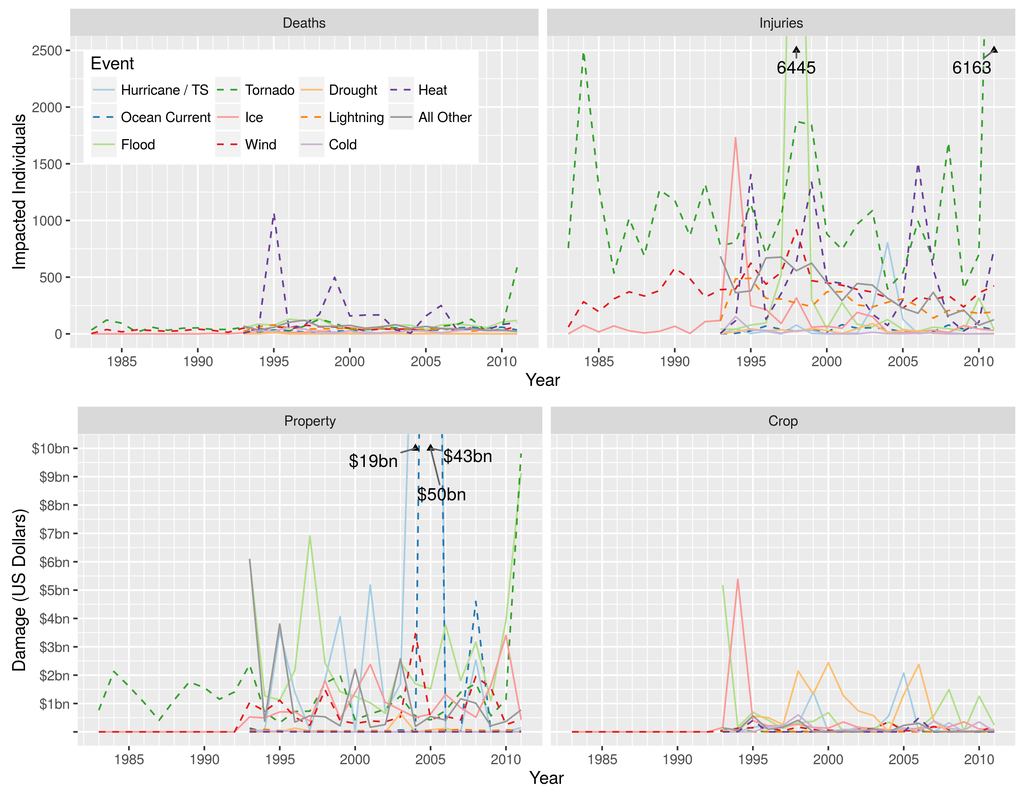

### Major Weather Threats by State

```r
## Organize the information by state, event and impact type for the
## most recent data.
stateMelt <- melt(data[data$Year >=minRecent,], id = c("State", "Event"),
                  measure.vars = c("Deaths", "Injuries", "Property", "Crop"))
## Collapse
byState   <- aggregate(value ~ State + Event + variable, stateMelt, sum)
names(byState)[3] <- "Impact"
## Not really needed, but makes exploring easier. Eliminate zeros:
byState   <- byState[ byState$value > 0, ]
## For each state and each impact type, what is the major event in recent years?
allStates <- unique(byState$State)  # should be 50
allTypes  <- unique(byState$Impact) # should be 4
aa <- length(allStates) * length(allTypes)
## Build a blank data frame with all State/Impact combinations:
maxState <- data.frame(State = rep(allStates, each = length(allTypes)),
                       Impact = rep(allTypes, times = length(allStates)),
                       Event  = vector("character", aa),
                       value  = vector("numeric", aa))
for (i in seq_len(nrow(maxState))) {
    ## What are the observed events for this state/impact
    all <- byState[ byState$State  == maxState$State[i] &
                    byState$Impact == maxState$Impact[i], c("Event", "value")]
    ## What's the maximal value?
    m <- ifelse(nrow(all) == 0, 0, max(all$value, na.rm = TRUE))
    maxState$value[i] <- m
    ## What event(s) does that represent?
    top <- as.character(all[ all$value == m, ][[1]])
    ## Which of those events were previously reported as a "major" event?
    tLogi <- top %in% topNames
    top <- sort(top[ tLogi ])
    numTop <- length(top)
    if (numTop == 0) {
        ## The major impact for this state is not a major category
        maxState$Event[i] <- otherLabel
    } else {
        maxState$Event[i] <- top[1]
        ## Warn if there were more than one top event. We just pick one
        if (numTop > 1) message
        (paste(c("Multiple maximal events",
                 as.character(maxState$State[i]),
                 as.character(maxState$Impact[i]), top),
               collapse = ' | '))
    }
}

## For coordinating colors make sure that the levels match those used before:
maxState$Event <- factor(maxState$Event, levels = levels(majorEvents$Event))

if (require("rgdal", quietly = TRUE)) {
    ## This block allows a very nice hexagonally-abstracted map to be used
    ## See Acknowlegments for main article, plus links to help install

    ## Because rgdal was a PAIN to install, this is not the default
    ## map to be drawn. It required a fair bit of tinkering outside of
    ## R to install the supporting packages

    ## sudo apt-get install libgdal-dev libproj-dev

    shownState <- "50 states"
    library("rgeos")
    library("maptools")
    library("mapproj")
    ## If you have it, then this code will make nice abstracted US maps:
    ## Organize regional information by hex map (Rbloggers@hrbrmstr)

    ## Yes, a hexagonal representation messes up some relationships;
    ## Many east coast states have lost access to the Atlantic, and
    ## Idaho suddenly has a Pacific coast. The Four Corners states
    ## must settle for Three Corners. But I think it really helps
    ## remove a lot of the distraction associated with a fine-grained
    ## US map.
    geojason <- "us_states_hexgrid.geojson"
    if (!file.exists(geojason)) {
        ## Download the hexagonal map specification:
        geourl <- "https://andrew.cartodb.com/api/v2/sql?filename=us_states_hexgrid&q=select+*+from+andrew.us_states_hexgrid&format=geojson&bounds=&api_key="
        download.file(geourl, geojason)
    }
    hex <- readOGR("us_states_hexgrid.geojson", "OGRGeoJSON", verbose = FALSE)
    hex_map <- fortify(hex, region="iso3166_2")
    hex_map <- inner_join(hex_map, maxState,by = c("id" = "State"))

    #ggplot(data=hex_map, aes(map_id = id, x=long, y=lat)) +
    #    geom_map(map=hex_map, color="black", fill="white")

    stateCen <- cbind.data.frame(data.frame(gCentroid(hex, byid=TRUE),
                                            id = hex@data$iso3166_2))
    us <- ggplot(hex_map) +
        geom_map( map = hex_map, color="white", size=0.5,
                 aes(x=long, y=lat, map_id = id, fill = Event)) +
        scale_fill_manual(values = majorColors) +
        facet_wrap( "Impact", nrow = 2)
    us <- us + geom_text(data= stateCen, aes(label=id, x=x, y=y),
                         color="white", size=4)
    ## coord_map() normalizes (somehow) the aspect ratio of the hexagons:
    us <- us + coord_map()
} else {
    ## If we can not get the slick hexagonal map to work, use a
    ## "normal" map of the lower 48.

    ##Need to be able to lookup mapping data by 2-letter abbreviation:
    shownState <- "contiguous 48 states"
    name2abbr <- data.frame( region = tolower(state.name), State = state.abb)
    states_map <- inner_join(map_data("state"), name2abbr, by = "region")
    ## inner_join is needed to keep polygons intact (SO@Richard Careaga)
    maxState$State <- as.character(maxState$State)
    stateImpact <- inner_join(states_map, maxState, by = "State")

    us <- ggplot(data = stateImpact,
                 aes(x = long, y = lat, fill = Event, group = group)) +
        geom_polygon() + facet_wrap( "Impact", nrow = 2)
}
```

[output not shown]

[output not shown]

```
## Checking rgeos availability: TRUE
```

```r
## Remove grid styling from around map (Rbloggers@hrbrmstr)
us <- us + labs(x=NULL, y=NULL) + theme_bw() +
    ggtitle(sprintf("Major Weather Hazard from %d to %d",minRecent, maxYear)) +
    theme(panel.border=element_blank()) + theme(panel.grid=element_blank()) +
    theme(axis.ticks=element_blank()) + theme(axis.text=element_blank())
```

Unsurprisingly, each state is exposed to slightly different weather risks. For example, it would be surprising to see hurricanes playing a major role in South Dakota. The maps below higlight the single top threat in each of the four casuality categories in each of the 50 states. Only those risks that are specifically highlighted; “All Other” indicates that the primary risk for that state falls outside those categories.

While tornadoes are a major threat even when averaged across the United States, the injury casualties show them concentrating around [Tornado Alley](https://en.wikipedia.org/wiki/Tornado_Alley) in the center of the US. Similarly, hurricanes and the effets from ocean currents are localized along the east coast and Gulf of Mexico. Flooding appears to be a truly national risk for monetary damages, spread extensively across the country.

Intriguingly, ice and cold are generally **not** the major factor in Northern states, nor heat for the Southern states (some exceptions). This could be beacause these states and their residents generally prepare adequately for their lattitude’s expected temperature extremes.

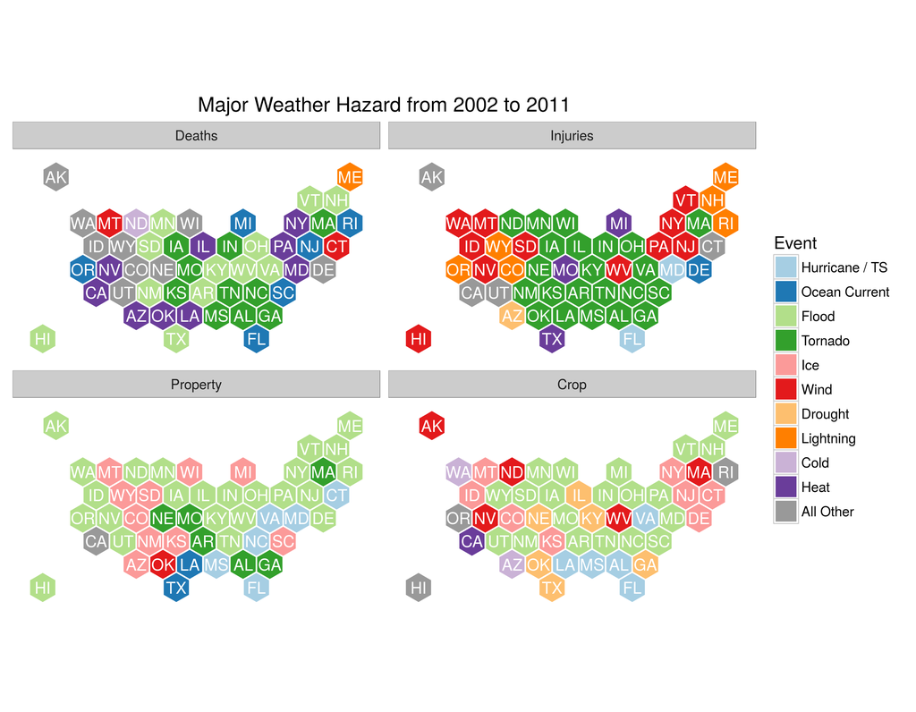

### Alignment with known major weather events.

- The [Great Flood of 1993](https://en.wikipedia.org/wiki/Great_Flood_of_1993) saw the Mississippi inflict 32 fatalities and over $10bn in losses in the Midwest.
- A major [ice storm in 1994](http://www.alabamawx.com/?p=5469) caused hundreds of injuries and billions in losses, including a quarter of Arkansas’ pecan industry.
- The [1995 heat wave](https://en.wikipedia.org/wiki/1995_Chicago_heat_wave) is visible as a major spike in fatalities.
- In 2005 [Hurricane Katrina](https://en.wikipedia.org/wiki/Hurricane_Katrina) wreaked havoc on the eastern seaboard. This is reflected in Hurricane and “Ocean Current” losses of US$93Bn. These values are likely under-estimates of the actual impact.
- 2011 was an [atypically destructive year for tornadoes](https://en.wikipedia.org/wiki/Tornadoes_of_2011#United_States_yearly_total), with nearly US$10bn in property damage. This includes the [Super Outbreak](https://en.wikipedia.org/wiki/2011_Super_Outbreak) in late April that claimed 363 lives, representing over half the fatalities shown in these data.

### Major Omissions

- Katrina caused over 1000 fatalities in the U.S. alone, but the data reflect only 150 deaths and few injuries for that time. It is possible that delayed casualties (those occuring days after the causative event) are being left out, even though the NOAA document indicates they should be included (eg injuries from using a kerosene heater due to a power failure)

## Thoughts on R / ggplot / etc

- I am dissatisfied with ggplot’s handling of outlier information. I would have liked to use a broken axis, but this is apparently [frowned upon by ggplot](https://stackoverflow.com/questions/7194688/using-ggplot2-can-i-insert-a-break-in-the-axis).
  - Possible in other packages, like [plotrix](https://stackoverflow.com/questions/24202245/grouped-barplot-with-cut-y-axis).
- Wow. The input data have records with un-escaped newlines. The good news is that `read.csv` appears to read these properly if they are properly quoted. The bad news is that it makes grepping in bash effectively impossible.
- Scientific notation (eg `1e+6`) appears to always be considered numeric by R, even if there is no decimal (dies on read.table if it occurs in an “integer” column).
- Control of how out-of-bounds values are handled in ggplot is still a mystery to me.

## Acknowledgements

- The knitr template is based on one devised by [Ron Ammar](https://github.com/ammarr), particularly the `rmarkdown` header and System Information section.
- Ron was generally helpful, particularly for plaintive requests for advice on ggplot.
- StackOverflow:
  - [ggrepel: Automatic handling of nearby geom_text](https://stackoverflow.com/a/34715743) - will “repel” text labels so they don’t overlap
  - [Using theme() to place legends inside plot](https://stackoverflow.com/a/28818021)
  - [Using gridExtra::grid.arrange() to organize ggplots](https://stackoverflow.com/a/7997671) - like `par(mfrow = c(1, 2))` but ggplot-friendly
  - [Properly merging data with US map](https://stackoverflow.com/a/26541278) - `merge` disrupts the polygon order, need to use `inner_join` instead
  - [Hexagonal US map layout](http://www.r-bloggers.com/geojson-hexagonal-statebins-in-r/)
    - [Map layout source](https://team.cartodb.com/u/andrew/tables/andrew.us_states_hexgrid/public/map)
    - [Installing rgdal](https://stackoverflow.com/questions/15248815/rgdal-package-installation)

## Appendix I - Event Aliases

These aliases were manually defined. In addition to the list below, regular expressions were used to assign events to Tornado, Hurricane / TS, Ice, Snow, Flood and Wind.

- **Cold:** `Cold`, `Cold and snow`, `Cold/wind chill`, `Extreme cold`, `Extreme cold/wind chill`, `Extreme windchill`, `Frost/freeze`
- **Drought:** `Drought`, `Dust storm`
- **Fire:** `Fire`, `Forest fires`, `Wildfire`, `Wildfires`, `Wild fires`, `Wild/forest fire`
- **Flood:** `Coastal flood`, `Coastal flooding`, `Flash flood`, `Flash flood/flood`, `Flash flooding`, `Flash flooding/flood`, `Flood/flash flood`, `Flooding`, `River flood`, `Urban flooding`, `Urban/sml stream fld`
- **Fog:** `Dense fog`, `Fog`, `Freezing fog`
- **Heat:** `Excessive heat`, `Extreme heat`, `Heat`, `Heat wave`, `Record/excessive heat`, `Record heat`, `Unseasonably warm`, `Unseasonably warm and dry`
- **Hurricane / TS:** `Hurricane`, `Hurricane felix`, `Hurricane/typhoon`, `Tropical storm`, `Tropical storm gordon`
- **Ice:** `Freeze`, `Freezing rain`, `Frost`, `Glaze`, `Hail`, `Ice`, `Ice on road`, `Ice storm`, `Small hail`, `Tstm wind/hail`
- **Ocean Current:** `Astronomical high tide`, `Astronomical low tide`, `Hazardous surf`, `Heavy surf`, `Heavy surf/high surf`, `High surf`, `Ocean Current`, `Rip current`, `Rip currents`, `Storm surge`, `Storm surge/tide`
- **Rain:** `Heavy rain`, `Rain`
- **Snow:** `Excessive snow`, `Heavy snow`, `Lake-effect snow`, `Light snow`, `Snow`, `Snow/high winds`
- **Tornado:** `Tornado`, `Tornadoes, tstm wind, hail`, `Waterspout`, `Waterspout/tornado`
- **Wind:** `Dry microburst`, `Dust devil`, `Dust storm/high winds`, `High wind`, `High winds`, `High winds/cold`, `Strong wind`, `Strong winds`, `Thunderstorm wind`, `Thunderstorm winds`, `Thunderstorm windss`, `Tstm wind`, `Wind`
- **Winter weather:** `Blizzard`, `Winter storm`, `Winter storms`, `Winter weather`, `Winter weather mix`, `Winter weather/mix`, `Wintry mix`

## System Information

*Time required to process this report:* *27.60523 secs*